# Disha_Project

## Setup

```r
library(knitr)
knitr::opts_chunk$set(echo = FALSE)
#knitr::opts_knit$set(root.dir= 'Users\AlstonQ\Documents\DR\')
knitr::opts_chunk$set(error = FALSE)
```

## Part 1: Data

In this case, the BRFSS Survey takes place every year from all 50 states and the District of Columbia, Puerto Rico, and Guam and collect survey data over a limited point- in-time (usually one to three months) from American Samoa, Federated States of Micronesia, and Palau. This makes the data generalized. The survey is conducted through both landline telephone and cellular telephone-based. In conducting the BRFSS landline telephone survey, interviewers collect data from a randomly selected adult in a household. In conducting the cellular telephone version of the BRFSS questionnaire, interviewers collect data from an adult who participates by using a cellular telephone and resides in a private residence or college housing. This makes the data collection random.

## Part 2: Research questions

**Research quesion 1:** Does the number of responses for general health of household depend on the last time they had a checkup?

**Research quesion 2:** People with children at home and how often they smoke and drink.

**Research quesion 3:** A person being detected with cholestrol as compared to his exercises and food?

## Part 3: Exploratory data analysis

**Research quesion 1:** Does the number of responses for general health of household depend on the last time they had a checkup?

The answer to question seems to be a no. As the amout of people who answer either of the options seem to fairly equal even though the last time they had a check up was 2 or 5 years ago or even never. This tells us how unreliable the data is until further investigation.

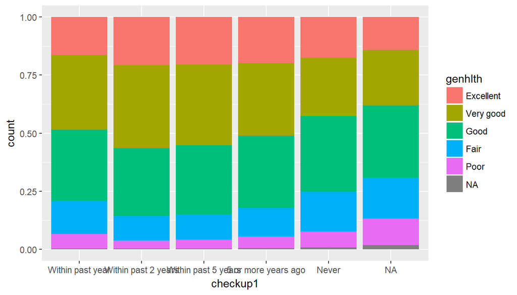

**Research quesion 2:** People with children at home and how often they smoke and drink.

The table shows the number of people who smoke(3 categories) and drink(0 or more than 100 drinks) with number of children in household. This data can help child services to identify children who might be affected by the adults and can be a victim of domestic violence.

```
##                   smokday2 Every day Some days Not at all
## children alccount
## 0        0                     18394      6456      51435
##          100                   19352      7923      58744
## 1        0                      3211      1090       4614
##          100                    3995      1780       6580
## 2        0                      2334       817       3204
##          100                    3081      1423       5931
## 3        0                      1117       356       1420
##          100                    1345       630       2178
## 4        0                       443       152        555
##          100                     445       208        596
## 5        0                       147        53        175
##          100                     154        65        165
## 6        0                        52        21         81
```

[output cut: 19 more lines]

**Research quesion 3:** A person being detected with cholestrol as compared to his exercises and food?

```
##                exerany2    Yes     No
## toldhi2 greens
## Yes     bad               7023   6865
##         good            111250  45505
## No      bad               8202   6500
##         good            157943  45057
```